# 第三次期中作業：ggplot2 + R Markdown

沈姝妤

29 Feb. 2017

### 第三次期中作業說明

練習使用 **ggplot2** 繪出『 *散佈圖、直方圖、線圖、盒鬚圖、長條圖* 』，並搭配 **R Markdown** 做呈現。 於 R 程式設計班 278 期，授課老師：郭耀仁。

### 資料庫使用

我使用了以下多種資料集：

- iris (樣本數: 150)
- economics (樣本數: 574)
- airquality (樣本數: 153)
- trees (樣本數: 31)

### 1. 散佈圖

1-1 概要：`iris 資料集`

用三種鳶尾花的萼片長寬以及花瓣長寬做出的資料集。

```
## 'data.frame':    150 obs. of  5 variables:
##  $ Sepal.Length: num  5.1 4.9 4.7 4.6 5 5.4 4.6 5 4.4 4.9 ...
##  $ Sepal.Width : num  3.5 3 3.2 3.1 3.6 3.9 3.4 3.4 2.9 3.1 ...
##  $ Petal.Length: num  1.4 1.4 1.3 1.5 1.4 1.7 1.4 1.5 1.4 1.5 ...
##  $ Petal.Width : num  0.2 0.2 0.2 0.2 0.2 0.4 0.3 0.2 0.2 0.1 ...
##  $ Species     : Factor w/ 3 levels "setosa","versicolor",..: 1 1 1 1 1 1 1 1 1 1 ...
```

1-2 圖表：散佈圖 + 線性關係

可看出若是以花瓣 (petal) 的 **長度** 及 **寬度** 之間的線性關係，三種鳶尾花算是一致的。

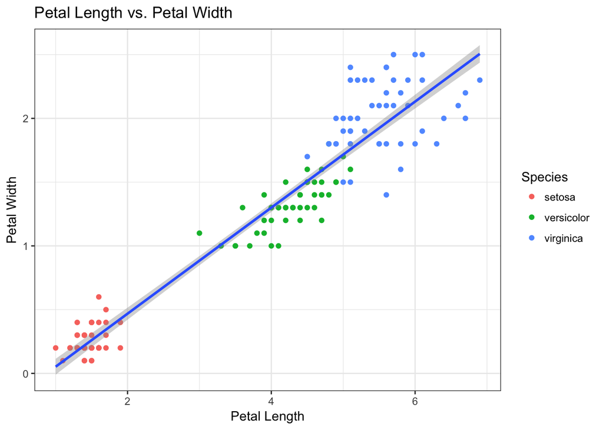

```r
ggplot(iris, aes(x = Petal.Length, y = Petal.Width, color = Species)) +
  geom_point() +
  ggtitle("Petal Length vs. Petal Width") + xlab("Petal Length") + ylab("Petal Width") +
  geom_smooth(aes(x = Petal.Length, y = Petal.Width), inherit.aes = FALSE, method = "lm") +
  # 補充：se = FALSE 可取消線性下方陰影。
  theme_bw() # 使用空白背景。
```

### 2. 直方圖

2-1 概要：如同 1-1 的 `iris 資料集`，此處不再重複贅述。

2-2 圖表：直方圖

使用三種鳶尾花的萼片 (sepal) 和花瓣 (petal) 寬度所呈現的直方圖。

發現以 **花瓣** 區分鳶尾花的種類會更清楚且容易，尤其是Setosa，可說是獨樹一格；

反觀 **萼片** 的結果，卻是離散到三個種類糾纏不清。

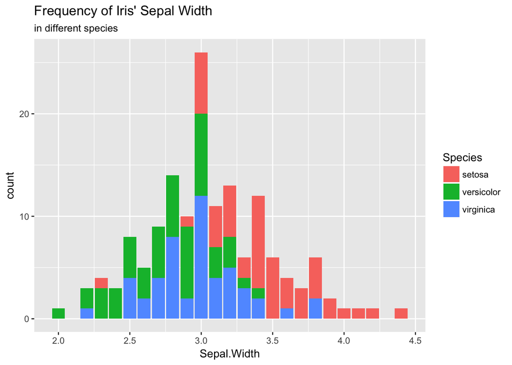

```r
ggplot(iris, aes(x = Sepal.Width)) +
  geom_bar(aes(fill = Species))+
  ggtitle("Frequency of Iris' Sepal Width", subtitle = "in different species")
```

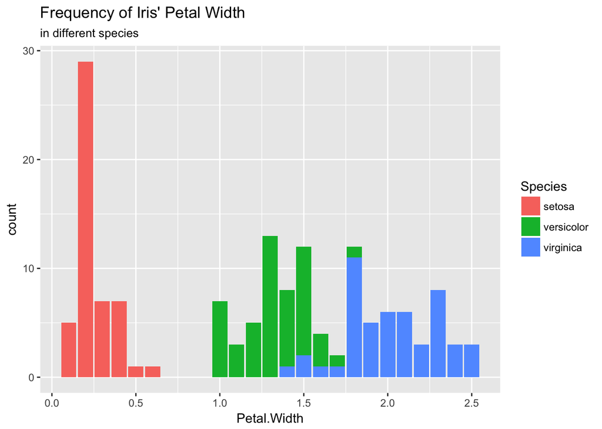

```r
ggplot(iris, aes(x = Petal.Width)) +
  geom_bar(aes(fill = Species))+
  ggtitle("Frequency of Iris' Petal Width", subtitle = "in different species")
```

### 3. 線圖

3-1 概要：`economics 資料集`

從 1967 七月到 2015 四月，美國經濟狀況，這次針對 **個人儲蓄指數** (personal saving rate) 描繪線圖。

```
## Classes 'tbl_df', 'tbl' and 'data.frame':    574 obs. of  6 variables:
##  $ date    : Date, format: "1967-07-01" "1967-08-01" ...
##  $ pce     : num  507 510 516 513 518 ...
##  $ pop     : int  198712 198911 199113 199311 199498 199657 199808 199920 200056 200208 ...
##  $ psavert : num  12.5 12.5 11.7 12.5 12.5 12.1 11.7 12.2 11.6 12.2 ...
##  $ uempmed : num  4.5 4.7 4.6 4.9 4.7 4.8 5.1 4.5 4.1 4.6 ...
##  $ unemploy: int  2944 2945 2958 3143 3066 3018 2878 3001 2877 2709 ...
```

3-2 圖表：線圖

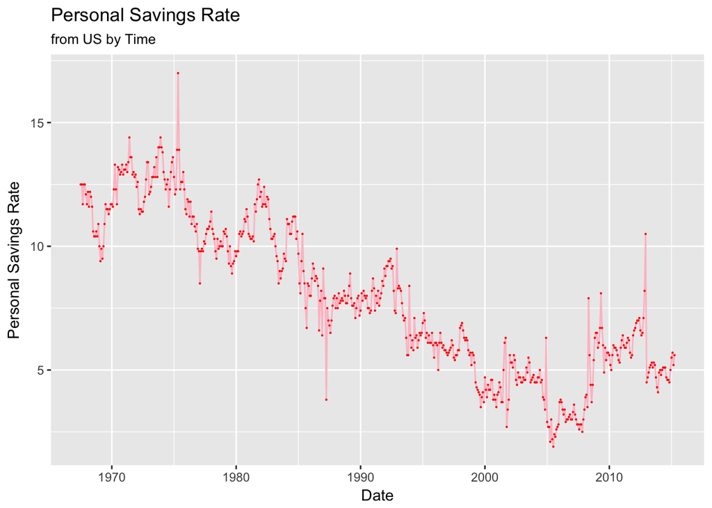

```r
ggplot(economics, aes(x = date, y = psavert)) +
  ggtitle("Personal Savings Rate", subtitle = "from US by Time") +
  xlab("Date") + ylab("Personal Savings Rate") +
  geom_line(colour = "pink") +
  geom_point(colour = "red", size = 0.1)
```

### 4. 盒鬚圖

4-1 概要：`airquality 資料庫`

於 1973 年五月到九月，紐約市的每天測量數值，包含了臭氧值 (ppb) 、風速 (mph) 、溫度 (度F) ⋯⋯等。

```
## 'data.frame':    153 obs. of  6 variables:
##  $ Ozone  : int  41 36 12 18 NA 28 23 19 8 NA ...
##  $ Solar.R: int  190 118 149 313 NA NA 299 99 19 194 ...
##  $ Wind   : num  7.4 8 12.6 11.5 14.3 14.9 8.6 13.8 20.1 8.6 ...
##  $ Temp   : int  67 72 74 62 56 66 65 59 61 69 ...
##  $ Month  : int  5 5 5 5 5 5 5 5 5 5 ...
##  $ Day    : int  1 2 3 4 5 6 7 8 9 10 ...
```

4-2 圖表：盒鬚圖

以五個月份做出紐約市的溫度做出盒鬚圖。

可看出七月的溫度離散最小，溫度集中偏高；

而五月氣溫偏低，卻同時也溫差大；

額外一提，溫差最大的約份是九月，可達 10 度 F。

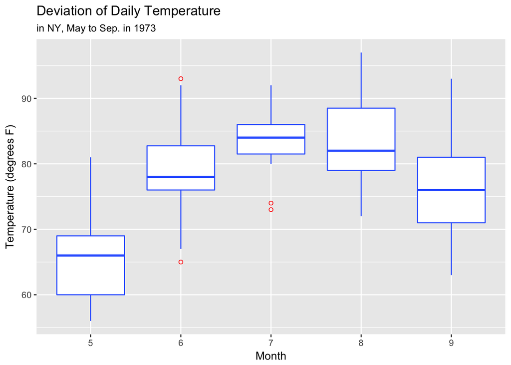

```r
airquality$Month <- as.factor(airquality$Month)
ggplot(airquality, aes(x = Month, y = Temp)) +
  geom_boxplot(fill = "white", colour = "#3366FF", outlier.colour = "red", outlier.shape = 1) +
  ggtitle("Deviation of Daily Temperature", subtitle = "in NY, May to Sep. in 1973") +
  ylab("Temperature (degrees F)")
```

### 5. 長條圖

5-1 概要：`trees 資料庫`

測量 31 個被砍伐的黑櫻樹的數值，其中有：周長 (inches)、高度 (ft) 、 木材體積 (cubic ft) 。

```
## 'data.frame':    31 obs. of  3 variables:
##  $ Girth : num  8.3 8.6 8.8 10.5 10.7 10.8 11 11 11.1 11.2 ...
##  $ Height: num  70 65 63 72 81 83 66 75 80 75 ...
##  $ Volume: num  10.3 10.3 10.2 16.4 18.8 19.7 15.6 18.2 22.6 19.9 ...
```

5-2 圖表：長條圖

使用黑櫻樹的高度做參數，並因資料庫只有 31 個，將組距設為十個。

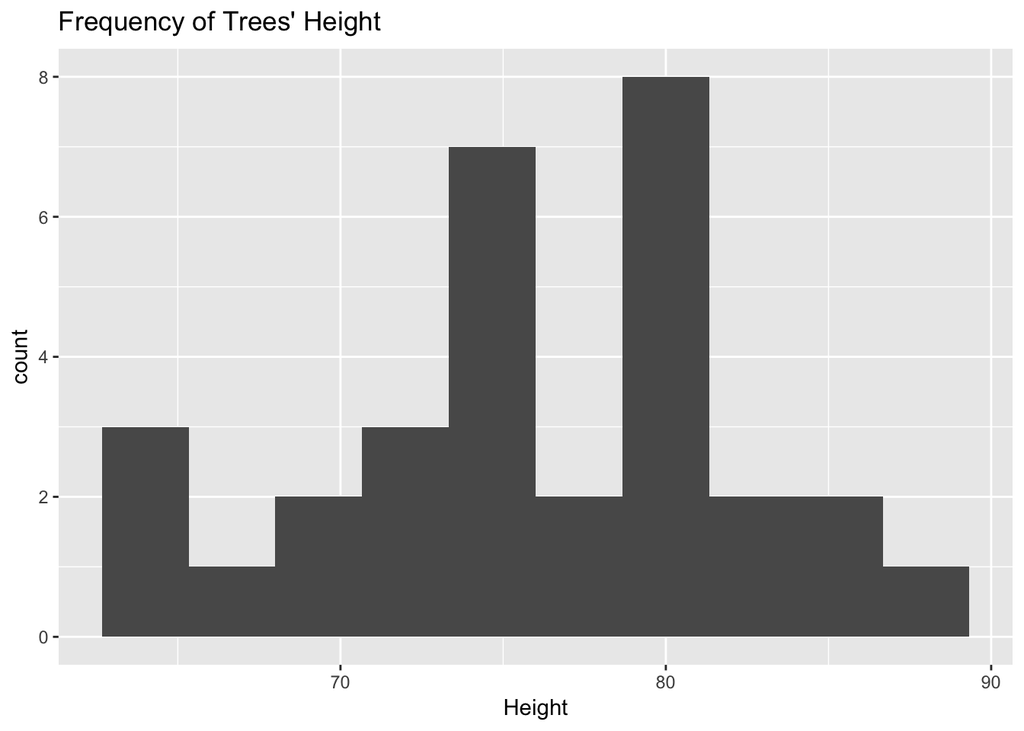

```r
ggplot(trees, aes(x = Height)) +
  ggtitle("Frequency of Trees' Height") +
  xlab("Height") +
  geom_histogram(bins = 10)
```

### 輕鬆時間

練習使用插圖：白痴卡通 **豆豆蟲**

[figure not shown]

### 參考連結

- [R Markdown - R Studio](http://rmarkdown.rstudio.com/index.html)
- [R 程式設計班課程 - 郭耀仁](https://yaojenkuo.github.io/r_programming/)